# Exam 3

## PART 2 (PREDICT TENURE) —————————————————

For Part 2 of this analysis, you will address the company’s second goal of using this data to create a model to predict a customer’s tenure (the number of days since the customers’ first purchase).

### Complete your exploratory data analysis (EDA) in this section. You may use multiple code chunks, if you wish, to organize your code.

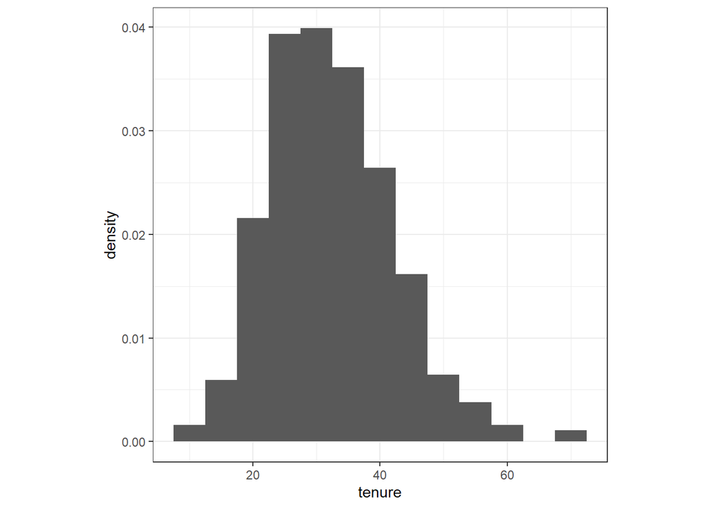

```r
snowshoe <- read.table("snowshoe.txt", header = TRUE) %>%
  mutate_if(is.character, as.factor) %>% mutate(snowshoes = as.factor(snowshoes))

#SET BASELINE winterSports
snowshoe <- within(snowshoe, product <- relevel(product, ref = 3))
tenure <- snowshoe %>% select(-tenure,everything())

tenure_hist <- ggplot(data = tenure) +
  geom_histogram(mapping = aes(x = tenure, y = ..density..),
                 binwidth = 5) +
  theme_bw() +
  theme(aspect.ratio = 1)
tenure_hist
```

### Perform variable selection in this section. You may use multiple code chunks, if you wish, to organize your code.

```r
tenure_best_subsets_bic <- bestglm(as.data.frame(tenure),
                                  IC = "AIC",
                                  method = "exhaustive",
                                  TopModels = 1,
                                  family = poisson)
```

```
## Morgan-Tatar search since family is non-gaussian.
```

```
## Note: factors present with more than 2 levels.
```

```r
summary(tenure_best_subsets_bic$BestModel)
```

```
##
## Call:
## glm(formula = y ~ ., family = family, data = Xi, weights = weights)
##
## Deviance Residuals:
##     Min       1Q   Median       3Q      Max
## -3.7855  -1.0661  -0.1119   0.8444   5.4774
##
## Coefficients:
##               Estimate Std. Error z value Pr(>|z|)
## (Intercept)  3.0451710  0.0338338  90.004  < 2e-16 ***
## quantity     0.0196830  0.0022244   8.849  < 2e-16 ***
## age          0.0053765  0.0006854   7.844 4.36e-15 ***
## snowshoes1  -0.0359986  0.0195447  -1.842   0.0655 .
## ---
## Signif. codes:  0 '***' 0.001 '**' 0.01 '*' 0.05 '.' 0.1 ' ' 1
##
## (Dispersion parameter for poisson family taken to be 1)
##
##     Null deviance: 1078.48  on 370  degrees of freedom
## Residual deviance:  880.62  on 367  degrees of freedom
## AIC: 2843.7
##
## Number of Fisher Scoring iterations: 4
```

### Fit a model using the variables you selected from the prevous section, and determine in any interaction(s) are needed for this model in this section. You may use multiple code chunks, if you wish, to organize your code.

```r
tenure_poisson <- glm(tenure ~ age + quantity, family = poisson, data = tenure)

summary(tenure_poisson)
```

```
##
## Call:
## glm(formula = tenure ~ age + quantity, family = poisson, data = tenure)
##
## Deviance Residuals:
##     Min       1Q   Median       3Q      Max
## -3.8712  -1.0869  -0.1285   0.8581   5.3750
##
## Coefficients:
##             Estimate Std. Error z value Pr(>|z|)
## (Intercept) 3.049584   0.033732  90.405  < 2e-16 ***
## age         0.005110   0.000670   7.626 2.42e-14 ***
## quantity    0.018828   0.002174   8.660  < 2e-16 ***
## ---
## Signif. codes:  0 '***' 0.001 '**' 0.01 '*' 0.05 '.' 0.1 ' ' 1
##
## (Dispersion parameter for poisson family taken to be 1)
##
##     Null deviance: 1078.48  on 370  degrees of freedom
## Residual deviance:  884.01  on 368  degrees of freedom
## AIC: 2845.1
##
## Number of Fisher Scoring iterations: 4
```

```r
snowshoe <- read.table("snowshoe.txt", header = TRUE) %>%
  mutate_if(is.character, as.factor) %>% mutate(snowshoes = as.factor(snowshoes))

#SET BASELINE winterSports
snowshoe <- within(snowshoe, product <- relevel(product, ref = 3))

tenure <- snowshoe %>% select(-tenure,everything())

tenure_poisson_int <- glm(tenure ~ .^2, family = poisson, data = tenure)
summary(tenure_poisson_int)
```

```
##
## Call:
## glm(formula = tenure ~ .^2, family = poisson, data = tenure)
##
## Deviance Residuals:
##     Min       1Q   Median       3Q      Max
## -3.8604  -1.0408  -0.1350   0.8957   5.1695
##
## Coefficients:
##                                    Estimate Std. Error z value Pr(>|z|)
## (Intercept)                       2.8614709  0.0853147  33.540  < 2e-16 ***
## quantity                          0.0372535  0.0095196   3.913  9.1e-05 ***
## age                               0.0098075  0.0017680   5.547  2.9e-08 ***
## productmountainSports             0.0615329  0.0828790   0.742   0.4578
## productwaterSports               -0.0883980  0.1141785  -0.774   0.4388
## snowshoes1                        0.0198239  0.0848945   0.234   0.8154
## quantity:age                     -0.0004078  0.0001760  -2.318   0.0205 *
## quantity:productmountainSports    0.0037668  0.0049841   0.756   0.4498
## quantity:productwaterSports       0.0021208  0.0089648   0.237   0.8130
## quantity:snowshoes1               0.0025462  0.0051827   0.491   0.6232
## age:productmountainSports        -0.0024585  0.0016516  -1.489   0.1366
## age:productwaterSports            0.0017114  0.0022970   0.745   0.4563
## age:snowshoes1                   -0.0014609  0.0015662  -0.933   0.3509
## productmountainSports:snowshoes1 -0.0236092  0.0489206  -0.483   0.6294
## productwaterSports:snowshoes1     0.0015375  0.0770050   0.020   0.9841
## ---
## Signif. codes:  0 '***' 0.001 '**' 0.01 '*' 0.05 '.' 0.1 ' ' 1
##
## (Dispersion parameter for poisson family taken to be 1)
##
##     Null deviance: 1078.48  on 370  degrees of freedom
## Residual deviance:  864.82  on 356  degrees of freedom
## AIC: 2849.9
##
## Number of Fisher Scoring iterations: 4
```

```r
new_tenure_poisson <- glm(tenure ~ quantity + age + quantity*age, family = poisson, data = tenure)
summary(new_tenure_poisson)
```

```
##
## Call:
## glm(formula = tenure ~ quantity + age + quantity * age, family = poisson,
##     data = tenure)
##
## Deviance Residuals:
##     Min       1Q   Median       3Q      Max
## -3.9231  -1.0386  -0.1259   0.8513   5.3196
##
## Coefficients:
##                Estimate Std. Error z value Pr(>|z|)
## (Intercept)   2.8652906  0.0761152  37.644  < 2e-16 ***
## quantity      0.0415927  0.0086370   4.816 1.47e-06 ***
## age           0.0089309  0.0015649   5.707 1.15e-08 ***
## quantity:age -0.0004533  0.0001670  -2.714  0.00664 **
## ---
## Signif. codes:  0 '***' 0.001 '**' 0.01 '*' 0.05 '.' 0.1 ' ' 1
##
## (Dispersion parameter for poisson family taken to be 1)
##
##     Null deviance: 1078.48  on 370  degrees of freedom
## Residual deviance:  876.67  on 367  degrees of freedom
## AIC: 2839.7
##
## Number of Fisher Scoring iterations: 4
```

```r
anova(tenure_poisson, new_tenure_poisson, test = "LRT")
```

```
## Analysis of Deviance Table
##
## Model 1: tenure ~ age + quantity
## Model 2: tenure ~ quantity + age + quantity * age
##   Resid. Df Resid. Dev Df Deviance Pr(>Chi)
## 1       368     884.01
## 2       367     876.67  1   7.3421 0.006736 **
## ---
## Signif. codes:  0 '***' 0.001 '**' 0.01 '*' 0.05 '.' 0.1 ' ' 1
```

### Based on your results above, fit an appropriate (“final”) model and check model assumptions in this section. You may use multiple code chunks, if you wish, to organize your code.

```r
# FINAL MODEL
new_tenure_poisson <- glm(tenure ~ quantity + age + quantity*age, family = poisson, data = tenure)
summary(new_tenure_poisson)
```

```
##
## Call:
## glm(formula = tenure ~ quantity + age + quantity * age, family = poisson,
##     data = tenure)
##
## Deviance Residuals:
##     Min       1Q   Median       3Q      Max
## -3.9231  -1.0386  -0.1259   0.8513   5.3196
##
## Coefficients:
##                Estimate Std. Error z value Pr(>|z|)
## (Intercept)   2.8652906  0.0761152  37.644  < 2e-16 ***
## quantity      0.0415927  0.0086370   4.816 1.47e-06 ***
## age           0.0089309  0.0015649   5.707 1.15e-08 ***
## quantity:age -0.0004533  0.0001670  -2.714  0.00664 **
## ---
## Signif. codes:  0 '***' 0.001 '**' 0.01 '*' 0.05 '.' 0.1 ' ' 1
##
## (Dispersion parameter for poisson family taken to be 1)
##
##     Null deviance: 1078.48  on 370  degrees of freedom
## Residual deviance:  876.67  on 367  degrees of freedom
## AIC: 2839.7
##
## Number of Fisher Scoring iterations: 4
```

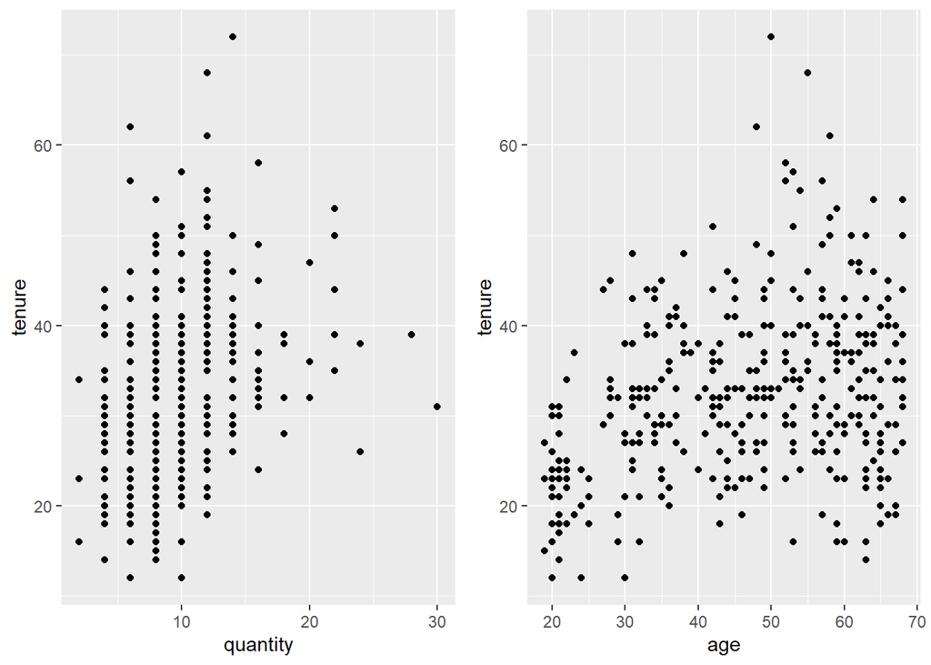

```r
#LINEARITY
scatter_quantity <- ggplot(tenure, aes(quantity, tenure)) +
  geom_point()

scatter_age <- ggplot(tenure, aes(age, tenure)) +
  geom_point()

grid.arrange(scatter_quantity,
             scatter_age,
             nrow = 1)
```

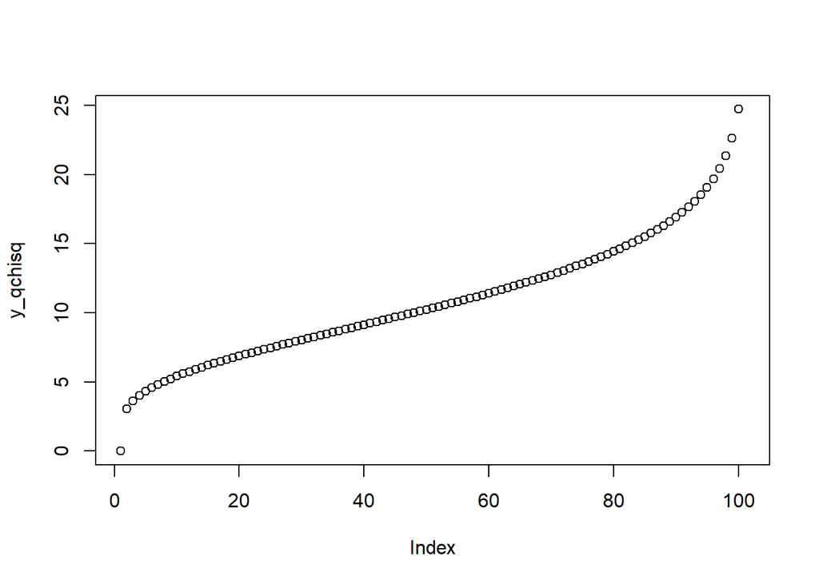

```r
# Mean = Var
x_qchisq <- seq(0, 1, by = 0.01)
y_qchisq <- qchisq(x_qchisq, df = 11)  # Apply qchisq function
plot(y_qchisq)
```

```r
model_2 <- update(new_tenure_poisson, .~. - quantity)
anova(model_2, new_tenure_poisson, test="Chisq")
```

```
## Analysis of Deviance Table
##
## Model 1: tenure ~ age + quantity:age
## Model 2: tenure ~ quantity + age + quantity * age
##   Resid. Df Resid. Dev Df Deviance  Pr(>Chi)
## 1       368     899.49
## 2       367     876.67  1   22.813 1.785e-06 ***
## ---
## Signif. codes:  0 '***' 0.001 '**' 0.01 '*' 0.05 '.' 0.1 ' ' 1
```

```r
tenure_quasi <- glm(tenure ~ ., family = quasipoisson, data = tenure)
summary(tenure_quasi)
```

```
##
## Call:
## glm(formula = tenure ~ ., family = quasipoisson, data = tenure)
##
## Deviance Residuals:
##     Min       1Q   Median       3Q      Max
## -3.8080  -1.1010  -0.1186   0.8458   5.3607
##
## Coefficients:
##                        Estimate Std. Error t value Pr(>|t|)
## (Intercept)            3.051778   0.054252  56.252  < 2e-16 ***
## quantity               0.019889   0.003498   5.685 2.68e-08 ***
## age                    0.005341   0.001081   4.942 1.18e-06 ***
## productmountainSports -0.027268   0.033764  -0.808    0.420
## productwaterSports     0.011096   0.045219   0.245    0.806
## snowshoes1            -0.037585   0.032317  -1.163    0.246
## ---
## Signif. codes:  0 '***' 0.001 '**' 0.01 '*' 0.05 '.' 0.1 ' ' 1
##
## (Dispersion parameter for quasipoisson family taken to be 2.45872)
##
##     Null deviance: 1078.48  on 370  degrees of freedom
## Residual deviance:  878.39  on 365  degrees of freedom
## AIC: NA
##
## Number of Fisher Scoring iterations: 4
```

### Complete statistical inference based on the best model you chose in this section. You may use multiple code chunks, if you wish, to organize your code.

```r
full_model <- glm(tenure ~ ., data = tenure)
lr.stat <- lrtest(full_model, new_tenure_poisson)
lr.stat
```

```
## Likelihood ratio test
##
## Model 1: tenure ~ quantity + age + product + snowshoes
## Model 2: tenure ~ quantity + age + quantity * age
##   #Df  LogLik Df  Chisq Pr(>Chisq)
## 1   7 -1333.6
## 2   4 -1415.9 -3 164.48  < 2.2e-16 ***
## ---
## Signif. codes:  0 '***' 0.001 '**' 0.01 '*' 0.05 '.' 0.1 ' ' 1
```

```r
predict(new_tenure_poisson,
        newdata = data.frame(age = 52, quantity = 10),
        level = 0.95,
        interval = "confidence",
        type = "response")
```

```
##        1
## 33.44477
```